# Here is your the report

You selected AK.

This is an example of a parameterized report in shiny. The markdown template is stored in the same location as the `app.R` file. There isn’t much to the markdown template except for the YAML setup. Here’s how the data is passed from shiny into the markdown file.

The YAML looks like this.

```r
---
output: html_document
params:
    selection: null
    data: null
---
```

I set each param to null in this example. If you want the document to render when the app is started, then set the params accordingly.

To access the params in the markdown file, use `params$some_param_name`. In this example, we will use `param$selection` and `param$data`. Define other parameters as needed.

In our shiny server code, we will use the function to `includeMarkdown()` and `render()` from the `rmarkdown` package to render out markdown template. We will also pass objects to our markdown template through the `render` function. Here’s what this function will look.

```r
includeMarkdown(
    rmarkdown::render("report_template.Rmd", params = list(selection = input$state, data = librariansDF()))
)
```

`librariansDF` is an object that is created when the render button is clicked and we can define the selection by calling `input$state`.

## Example Plot

Now that we have our params defined and passed data into them. Let’s use them.

```r
# find top areas by selected state
top_ten <- params$data %>%
    group_by(area_name) %>%
    summarize("tot_emp" = sum(tot_emp)) %>%
    top_n(10) %>%
    arrange(tot_emp) %>%
    mutate(area_name = factor(area_name, area_name))
```

Here’s the chart.

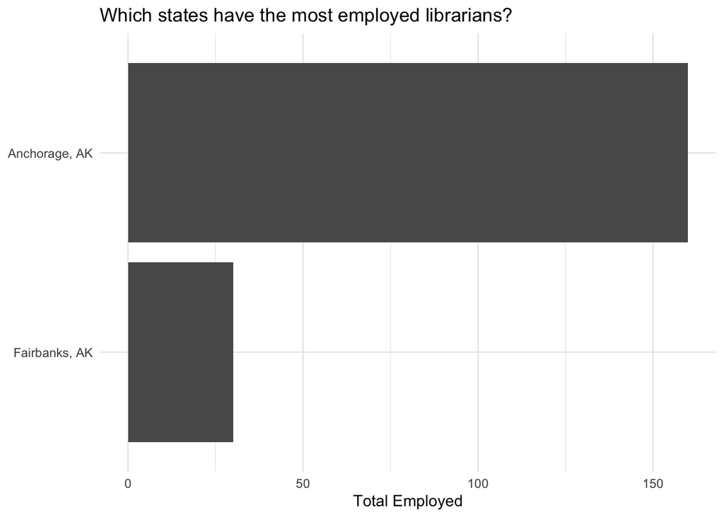

Here’s the table.

| area_name | tot_emp |
| --- | --- |
| Fairbanks, AK | 30 |
| Anchorage, AK | 160 |

For more information on parameterized reports, check out the [documentation](https://rmarkdown.rstudio.com/developer_parameterized_reports.html%23parameter_types%2F).